```r
library(readxl)
library(corrplot)
library(lm.beta)
library(Hmisc)
library(qgraph)
library(plyr)
library(dplyr)
library(psych)
library(neurobase)
library(oro.nifti)
library(dplyr)
library(png)
library(ggiraphExtra)
library(data.table)
library(cowplot)
library(ggplot2)
library(patchwork)
# library(NMF)
library(ggbeeswarm)
#source("/Volumes/Users/nfranzme/R_Projects/R_Imaging/workbench/workbench_map_volume_to_surface#.R")
library(ggpubr)
library(lubridate)
library(reticulate)
library(svMisc)
library(NetworkToolbox)
library(readxl)
library(writexl)
library(lme4)
library(lmerTest)
library(stringr)
library(boot)
library(table1)
dir.root = "/Volumes/NO NAME/fMRI_Day2_Graph_Theory/"
ADNI.data.bl.graphtheory <- readxl::read_xlsx(
  paste0(dir.root, "/data_sheets/ADNI_fMRI_PET_GraphTheory.xlsx"))

ADNI.data.bl.graphtheory$DX.Ab <- factor(ADNI.data.bl.graphtheory$DX.Ab,
                          levels = c("CN.Ab.neg",
                                     "CN.Ab.pos",
                                     "MCI.Ab.pos",
                                     "Dementia.Ab.pos"))
```

### What happens to the default mode network (DMN) in Alzheimer’s disease patients?

Previous studies have suggested that the DMN is disrupted in Alzheimer’s disease patients. Attached, find a figure from a cohort with autosomal dominantly inherited AD patients (i.e. a rare genetic form of the disease, which becomes symptomatic around the age of 40). Here, you can clearly see that the DMN becomes less pronounced in patients with autosomal dominantly inherited AD (right) vs. controls (left). By the way, if you want to learn more about the DMN, I recommend this excellent review by Randy Buckner: https://www.nature.com/articles/s41583-019-0212-7

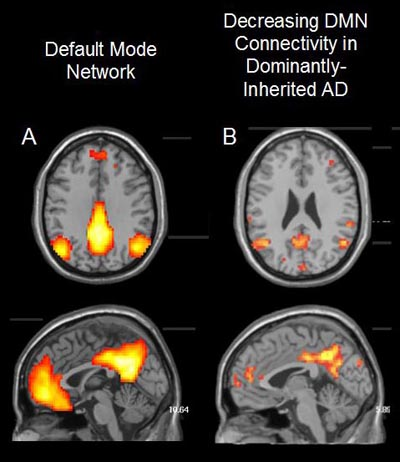

Similar observations of DMN disruption have been made in patients with sporadic AD. The DMN has been suggested to be crucial for episodic memory performance, hence DMN disruptions have been argued to drive memory decline.

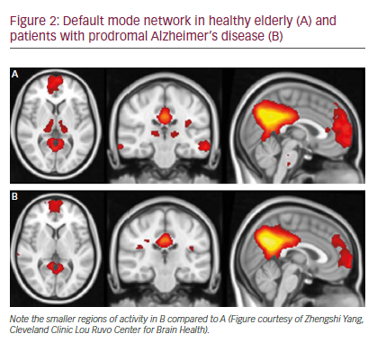

#### Does DMN connectivity change across the spectrum of AD

First, lets plot a simple measure of within DMN connectivity across controls and AD patients. We have computed this measure in our for-loop and saved it as *network.connectivity.within.DMN* in the *ADNI.data.bl.graphtheory* data frame. We use ggplot again to create a figure

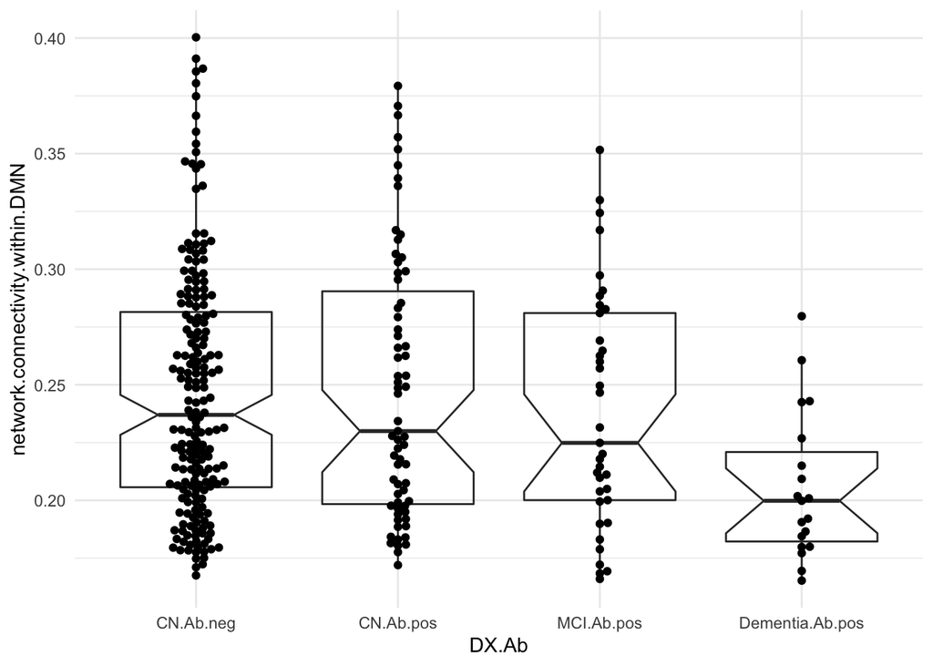

```r
ggplot(data = ADNI.data.bl.graphtheory,
       aes(
         x = DX.Ab,
         y = network.connectivity.within.DMN)) +
  geom_boxplot(notch = T, alpha = 0.1) +
  geom_beeswarm() +
  theme_minimal()
```

As you can see, there is a decrease in DMN connectivity across the AD spectrum. But is this decrease significant? Lets use an ANCOVA to test this.

```r
tmp.aov <- aov(data = ADNI.data.bl.graphtheory,
               network.connectivity.within.DMN ~ DX.Ab + age + sex); summary(tmp.aov)
```

```
##              Df Sum Sq  Mean Sq F value  Pr(>F)
## DX.Ab         3 0.0317 0.010579   3.936 0.00886 **
## age           1 0.0099 0.009858   3.668 0.05640 .
## sex           1 0.0241 0.024105   8.969 0.00297 **
## Residuals   309 0.8305 0.002688
## ---
## Signif. codes:  0 '***' 0.001 '**' 0.01 '*' 0.05 '.' 0.1 ' ' 1
```

Indeed, the data shows that the connectivity within the DMN decreases across the AD spectrum.

```r
TukeyHSD(tmp.aov, which = "DX.Ab")
```

```
##   Tukey multiple comparisons of means
##     95% family-wise confidence level
##
## Fit: aov(formula = network.connectivity.within.DMN ~ DX.Ab + age + sex, data = ADNI.data.bl.graphtheory)
##
## $DX.Ab
##                                    diff         lwr          upr     p adj
## CN.Ab.pos-CN.Ab.neg         0.001464213 -0.01753724  0.020465663 0.9972029
## MCI.Ab.pos-CN.Ab.neg       -0.008160736 -0.03220387  0.015882401 0.8169144
## Dementia.Ab.pos-CN.Ab.neg  -0.041177880 -0.07338402 -0.008971739 0.0058690
## MCI.Ab.pos-CN.Ab.pos       -0.009624949 -0.03705353  0.017803628 0.8014350
## Dementia.Ab.pos-CN.Ab.pos  -0.042642093 -0.07744856 -0.007835630 0.0092136
## Dementia.Ab.pos-MCI.Ab.pos -0.033017144 -0.07081274  0.004778455 0.1106865
```

A post-hoc Tukey test shows that the patients with AD dementia mostly drive this effect

Next, lets have a look whether the connectivity of the DMN to the remainig brain also changes across the AD spectrum. We have also computed this measure in our for-loop and saved it as *network.connectivity.between.DMN* in the *ADNI.data.bl.graphtheory* data frame. So same procedure as above….

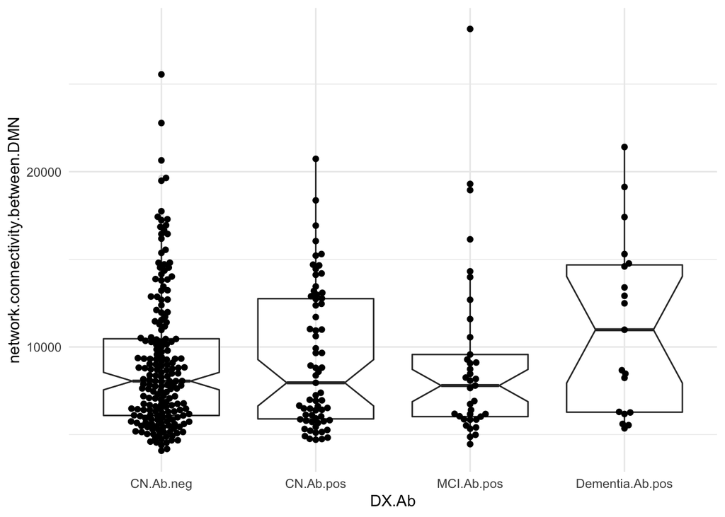

```r
ggplot(data = ADNI.data.bl.graphtheory,
       aes(
         x = DX.Ab,
         y = network.connectivity.between.DMN)) +
  geom_boxplot(notch = T, alpha = 0.1) +
  geom_beeswarm() +
  theme_minimal()
```

As you can see, there is a rather an increase in DMN connectivity to the remaining brain across the AD spectrum. This suggests some sort of de-differentiation of network activity (i.e. reduced within but increased between network connectivity) But is this decrease significant?

```r
tmp.aov <- aov(data = ADNI.data.bl.graphtheory,
               network.connectivity.between.DMN ~ DX.Ab + age + sex + PTEDUCAT); summary(tmp.aov)
```

```
##              Df    Sum Sq   Mean Sq F value   Pr(>F)
## DX.Ab         3 8.180e+07  27267025   1.658 0.176116
## age           1 4.469e+07  44686739   2.717 0.100309
## sex           1 1.931e+08 193068744  11.738 0.000695 ***
## PTEDUCAT      1 3.394e+07  33936798   2.063 0.151895
## Residuals   308 5.066e+09  16447579
## ---
## Signif. codes:  0 '***' 0.001 '**' 0.01 '*' 0.05 '.' 0.1 ' ' 1
```

Nope….So to sum up: What we find is a decrease in DMN connectivity across the AD spectrum. But is this decrease in connectivity really related to memory? Lets have a look at a scatterplot first

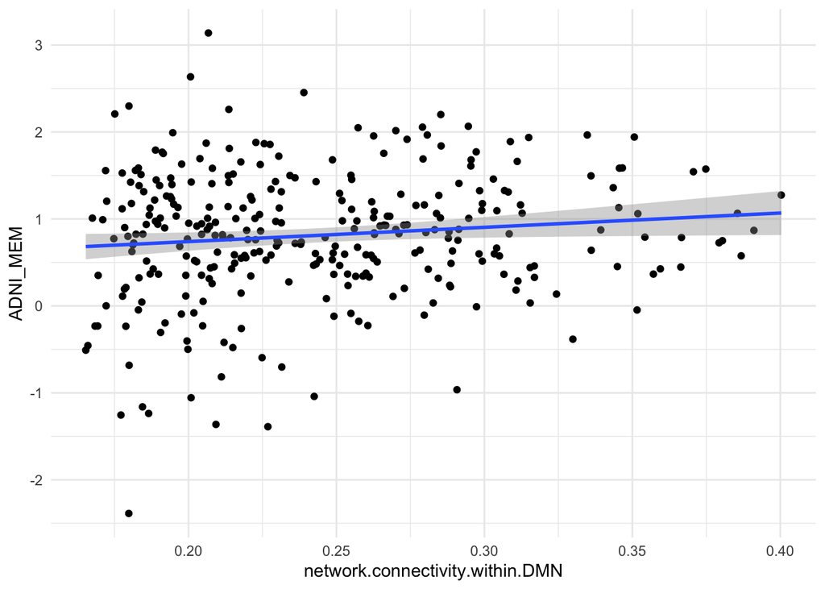

```r
ggplot(data = ADNI.data.bl.graphtheory,
       aes(
         x = network.connectivity.within.DMN,
         y = ADNI_MEM)) +
  geom_point() +
  geom_smooth(method = "lm") +
  theme_minimal()
```

Next, lets check the correlation between DMN connectivity and memory performance

```r
# compute correlation
rcorr(ADNI.data.bl.graphtheory$network.connectivity.within.DMN,
      ADNI.data.bl.graphtheory$ADNI_MEM)
```

```
##      x    y
## x 1.00 0.12
## y 0.12 1.00
##
## n
##     x   y
## x 315 314
## y 314 314
##
## P
##   x      y
## x        0.0359
## y 0.0359
```

Looks like there is a slight correlation between decreasing within DMN connectivity and decreasing memory performance. But keep in mind that “healthy controls” (i.e. CN.Ab.neg) are also included in this plot and the correlation analysis. So in order to specifically investigate the role of the DMN in AD patients, we need to create a subset of the data, that is restricted to AD patients. To this end, we subset the data fram *ADNI.data.bl.graphtheory* to subjects whose diagnosis is unequal to (i.e. *!=*) *“CN.Ab.neg”*.

```r
# we store our subset in a dedicated data frame
ADNI.data.bl.graphtheory.AD.only <- subset(ADNI.data.bl.graphtheory, DX.Ab!="CN.Ab.neg")
```

Now we’re left with AD patients only as you can see from the table below.

```r
table(ADNI.data.bl.graphtheory.AD.only$DX.Ab)
```

```
##
##       CN.Ab.neg       CN.Ab.pos      MCI.Ab.pos Dementia.Ab.pos
##               0              67              37              19
```

So lets have a look again at the association between network connectivity and memory performance, using our subset of AD patients only:

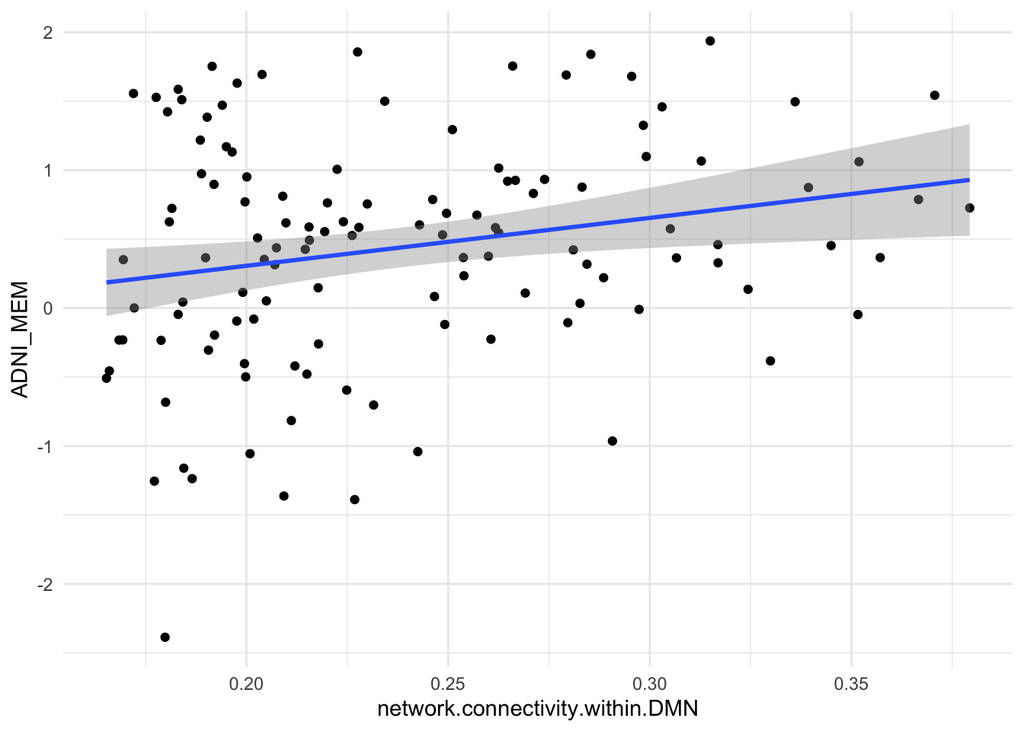

```r
ggplot(data = ADNI.data.bl.graphtheory.AD.only,
       aes(
         x = network.connectivity.within.DMN,
         y = ADNI_MEM)) +
  geom_point() +
  geom_smooth(method = "lm") +
  theme_minimal()
```

```r
# compute correlation
rcorr(ADNI.data.bl.graphtheory.AD.only$network.connectivity.within.DMN,
      ADNI.data.bl.graphtheory.AD.only$ADNI_MEM)
```

```
##      x    y
## x 1.00 0.23
## y 0.23 1.00
##
## n= 123
##
##
## P
##   x      y
## x        0.0117
## y 0.0117
```

Looks a bit stronger! So together, we found that DMN connectivity decreases across the AD spectrum, and that a decrease in DMN connectivity is associated with lower memory performance.